# Weekly Sales Forecast for Big Box, Inc.

Big Box, Inc. requested a forecast of weekly sales for the individual deparments in each of its stores. The company provided the data team with three CSV files containing data related to its stores and their departments, weekly sales, and economic and weather conditions in the geographic areas where stores are located. Specifically Big Box requested a forecast of the next three months beyond the actual sales data provided.

We performed a time series analysis through the following phases:

# Time Series Analysis Phases

1. [Data Import, Validation, and Merge](https://mstuartproj.github.io/sales_forecast/Sales_Forecast_1.html)
2. [Exploratory Data Analysis: Stores, Departments, and Total Sales](https://mstuartproj.github.io/sales_forecast/Sales_Forecast_2.html)
3. [Exploratory Data Analysis: Weekly Sales](https://mstuartproj.github.io/sales_forecast/Sales_Forecast_3.html)
4. [Feature Creation and Selection](https://mstuartproj.github.io/sales_forecast/Sales_Forecast_4.html)
5. [Modeling and Prediction: Random Forest Regression](https://mstuartproj.github.io/sales_forecast/Sales_Forecast_5.html)
6. [Modeling and Prediction: SARIMA](https://mstuartproj.github.io/sales_forecast/Sales_Forecast_6.html)

[figure not shown]

# Phase 4. Feature Selection and Creation

## Correlations Between Features

To explore the relationship between features, we created a heatmap showing a correlation matrix. There did not appear to be a strong relationship between the features, with the exception of one pair of Markdown features. There was not a strong correlation between any of the features and weekly sales, which is our target for forecasting.

We noted these relationships:

- Most features had a low degree of correlation with other features (less than ± 0.30).
- Looking at the vertical column for weekly sales, which was being forecasted, most other features had near zero correlation. Weekly sales had low correlation with the size of the store (0.24).
- There were two pairs of features with higher correlations values, namely between the markdowns and whether the week was associated with holiday. For example the holiday weeks and markdown 3 had a moderate correlation (0.50). Furthermore the holiday weeks and markdown 2 had a moderate correlation (0.39).
- Markdown 1 and Markdown 4 had the only strong correlation (0.84).

[figure not shown]

```python
import matplotlib.pyplot as plt
import numpy as np
import pandas as pd
import seaborn as sns
from sklearn.preprocessing import OneHotEncoder
```

```python
#Read in fulldata.csv
fulldata = pd.read_csv('data_merged/fulldataset.csv', index_col = 0)
```

```
[]
```

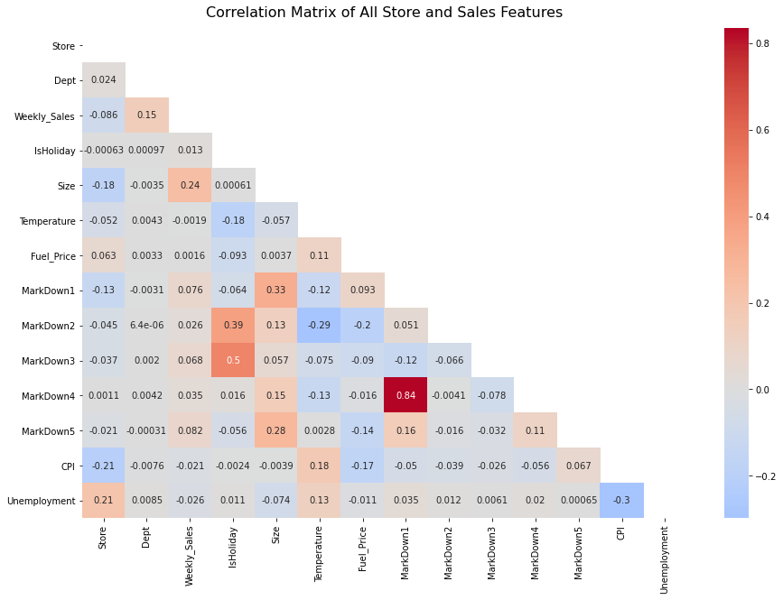

```python
#Show any correlations between features using a heatmap
corr = fulldata.corr(method = 'pearson')
mask = np.zeros_like(corr, dtype=np.bool)
mask[np.triu_indices_from(mask)] = True

plt.figure(figsize=(15,10))
heatmap = sns.heatmap(corr, annot=True, mask=mask, cmap='coolwarm', center=0)
heatmap.set_title('Correlation Matrix of All Store and Sales Features',
                  fontdict={'fontsize':16}, pad=12)
plt.plot()
```

[figure not shown]

## Preprocessing, Selection, and Creation of Features

We defined and called a function to perform the preprocessing steps needed to prepare the data for modeling. The function performs these steps:

- Recoded the Date feature as two new numerical features representing the week number and the year. The first date in the provided data set is week number 5 of the year 2010.
- Recoded the IsHoliday features as numerical 0=False and 1=True.
- Recoded the store Type as three new features using One Hot Encoding. The new features were numerical TypeA, TypeB, and TypeC whose values are 0=False and 1=True.
- Dropped the original Type and IsHoliday features, but kept the Date feature temporarily. The Date feature was needed later when splitting the training and validation sets.
- Dropped the markdown features. This data is very incomplete. Future analysis can include these features when more data is available.

[figure not shown]

```python
def preprocess(thedataset):

    #Convert the date to a week number
    #The earliest date of 2010-02-05 is in week number 5 of the year
    tempdate = pd.to_datetime(thedataset['Date'])
    thedataset['Year'] = tempdate.dt.year
    thedataset['WeekNum'] = tempdate.dt.isocalendar().week

    #Recode the IsHoliday as False=0 and True=1
    thedataset['IsHolidayInt'] = thedataset['IsHoliday'].astype(int)

    #Recode the store type as separate features using one hot encoding
    onehotencoder = OneHotEncoder(handle_unknown='ignore')
    typearray = onehotencoder.fit_transform(thedataset[['Type']]).toarray()
    typedata = pd.DataFrame(typearray)
    thedataset['TypeA'] = typedata[0]
    thedataset['TypeB'] = typedata[1]
    thedataset['TypeC'] = typedata[2]

    #Drop the IsHoliday column because we recoded it as numeric
    thedataset = thedataset.drop(columns=['IsHoliday'])

    #Drop the Type column because we recoded it as numeric
    thedataset = thedataset.drop(columns=['Type'])

    #Drop the markdowns as they are very incomplete.
    #Future analysis can encorporate these when more data is available.
    thedataset = thedataset.drop(columns=['MarkDown1'])
    thedataset = thedataset.drop(columns=['MarkDown2'])
    thedataset = thedataset.drop(columns=['MarkDown3'])
    thedataset = thedataset.drop(columns=['MarkDown4'])
    thedataset = thedataset.drop(columns=['MarkDown5'])

    return thedataset
```

```python
#Call the function to recode features, create new ones, and drop those we don't need
finalfeatureset = preprocess(fulldata)

finalfeatureset.head()
```

|  | Store | Dept | Date | Weekly_Sales | Size | Temperature | Fuel_Price | CPI | Unemployment | Year | WeekNum | IsHolidayInt | TypeA | TypeB | TypeC |
| --- | --- | --- | --- | --- | --- | --- | --- | --- | --- | --- | --- | --- | --- | --- | --- |
| 0 | 1 | 1 | 2010-02-05 | 24924.50 | 151315 | 42.31 | 2.572 | 211.096358 | 8.106 | 2010 | 5 | 0 | 1.0 | 0.0 | 0.0 |
| 1 | 1 | 1 | 2010-02-12 | 46039.49 | 151315 | 38.51 | 2.548 | 211.242170 | 8.106 | 2010 | 6 | 1 | 1.0 | 0.0 | 0.0 |
| 2 | 1 | 1 | 2010-02-19 | 41595.55 | 151315 | 39.93 | 2.514 | 211.289143 | 8.106 | 2010 | 7 | 0 | 1.0 | 0.0 | 0.0 |
| 3 | 1 | 1 | 2010-02-26 | 19403.54 | 151315 | 46.63 | 2.561 | 211.319643 | 8.106 | 2010 | 8 | 0 | 1.0 | 0.0 | 0.0 |
| 4 | 1 | 1 | 2010-03-05 | 21827.90 | 151315 | 46.50 | 2.625 | 211.350143 | 8.106 | 2010 | 9 | 0 | 1.0 | 0.0 | 0.0 |

[figure not shown]

## Create the training set and validation set

We split the full feature set into a training set and a validation set based on dates. We dropped the Date column prior to saving the data sets as separate CSV files.

- The **training set** contains 80% of the rows and it ranges from 2/5/2010 to 1/31/2012.
- The **validation set** contains 13% of the row and it ranges from 4/1/2012 to 7/31/2012.

> NOTE: The cutoff dates leave an unused set of 7% of the rows that range from 2/1/2012 to 3/31/2012.

[figure not shown]

```python
#The training set has 80% (79.9%) of the rows
startdate = "2010-02-05"
enddate = "2012-01-31"
#These lines create a pandas Series object of boolean values
#which will be used to index finalfeatureset
after_startdate = finalfeatureset['Date'] >= startdate
before_enddate = finalfeatureset['Date'] <= enddate
between_two_dates = after_startdate & before_enddate
#Filter for the rows that are within the date range
training_set = finalfeatureset.loc[between_two_dates]
#Reset the values in the index column to be sequential
training_set.reset_index(drop=True, inplace=True)
```

```python
#The unused set has 7.0% of the rows
startdate = "2012-02-01"
enddate = "2012-03-31"
#These lines create a pandas Series object of boolean values
#which will be used to index finalfeatureset
after_startdate = finalfeatureset['Date'] >= startdate
before_enddate = finalfeatureset['Date'] <= enddate
between_two_dates = after_startdate & before_enddate
#Filter for the rows that are within the date range
unused_set = finalfeatureset.loc[between_two_dates]
#Reset the values in the index column to be sequential
unused_set.reset_index(drop=True, inplace=True)
```

```python
#The validation_set has 13% (13.1%) of the rows
startdate = "2012-04-01"
enddate = "2012-07-31"
#These lines create a pandas Series object of boolean values
#which will be used to index finalfeatureset
after_startdate = finalfeatureset['Date'] >= startdate
before_enddate = finalfeatureset['Date'] <= enddate
between_two_dates = after_startdate & before_enddate
#Filter for the rows that are within the date range
validation_set = finalfeatureset.loc[between_two_dates]
#Reset the values in the index column to be sequential
validation_set.reset_index(drop=True, inplace=True)
```

```python
#Save the training set to CSV with dates and also without dates.
#The dates should be removed for modeling, since these were recoded
#as week numbers and years. But the dates are needed for later
#plotting of predictions vs actual sales.
training_set.to_csv('data_merged/trainingdata_withdates.csv')
training_set = training_set.drop(columns=['Date'])
training_set.to_csv('data_merged/trainingdata.csv')
```

```python
#Save the unused set to CSV with dates and also without dates.
#These are not actually used in the analysis
unused_set.to_csv('data_merged/unuseddata_withdates.csv')
unused_set = unused_set.drop(columns=['Date'])
unused_set.to_csv('data_merged/unuseddata.csv')
```

```python
#Save the validation set to CSV with dates and also without dates.
#The dates should be removed for modeling, since these were recoded
#as week numbers and years. But the dates are needed for later
#plotting of predictions vs actual sales.
validation_set.to_csv('data_merged/validationdata_withdates.csv')
validation_set = validation_set.drop(columns=['Date'])
validation_set.to_csv('data_merged/validationdata.csv')
```